# Monte Carlo Simulations

Carlos Calvo Hernandez

5/22/2019

# Monte Carlo in R

The MonteCarlo package[^1] for the R language provides tools to create simulation studies quickly and easily and it also allows to summarize the results in LaTeX tables. This vignette gives details on the implementation of the MonteCarlo package and presents examples for its application.

There are only two main functions in the package:

1. *MonteCarlo()* runs a simulation study for a user defined parameter grid. It handles the generation of loops over these parameter grid and parallelizes the computation on a user specified number of CPUs.
2. *MakeTable()* creates LaTeX tables from the output of *MonteCarlo()*. It stacks high dimensional output arrays into tables with a user specified ordering of rows and columns.

The idea behind this approach is to allow the user full control and flexibility with regard to the design of the Monte Carlo experiment. It also makes *MonteCarlo()* very versatile. Finally, it is very intuitive. The user formulates his experiment as if he/she was only interested in a single draw.

## A First Example

The best way to get working with the MonteCarlo package is to look at an example. Here we evaluate the performance of a standard t-test of the hypothesis $H_0: \mu=0$ vs $H_1: \mu\neq0$. We are interested to see how the size and power of the test change with the sample size (*n*), the distance from the null hypothesis (*loc* - for location) and the standard deviation of the distribution (*scale*).

The test statistic is given by

where $\bar x$ and $\hat \sigma$ are the arithmetic mean and the estimated standard deviation. The sample is generated from a normal distribution.

To conduct this analysis, we proceed as follows. First, we load the MonteCarlo package.

```r
library(MonteCarlo)
set.seed(1234)
```

Then we define the following function.

```r
##      Example: t-test
# Define function that generates data and applies the method of interest
ttest<-function(n,loc,scale){

  # generate sample:
    sample <- rnorm(n, loc, scale)

  # calculate test statistic:
    stat <-sqrt(n) *mean(sample) / sd(sample)

  # get test decision:
    decision <- abs(stat)>1.96

  # return result:
    return(list("stat" = stat, "decision" = decision))
}
```

As discussed above, *ttest()* is formulated in a way as if we only want to generate a single test decision. The arguments of the function are the parameters we are interested in.

Our *ttest()* function carries out 4 steps:

1. Draw a sample of *n* observations from a normal distribution with mean $\mu=loc$ and standard deviation $\sigma=scale$.
2. Calculate the t-statistic.
3. Determine the test decision.
4. Return the desired result in form of a list.

Then, we define the combinations of parameters that we are interested in and collect them in a list. The elements of this list must have the same names as the parameters for which we want to supply grids.

```r
# define parameter grid:
  n_grid<-c(50,100,250,500)
  loc_grid<-seq(0,1,0.2)
  scale_grid<-c(1,2)

# collect parameter grids in list:
  param_list=list("n"=n_grid, "loc"=loc_grid, "scale"=scale_grid)
```

To run the simulation, the function *ttest()* and the parameter grid (*param_list*) are passed to *MonteCarlo()*, together with the desired number of Monte Carlo repetitions (here *nrep=1000*).

```r
# run simulation
MC_result<-MonteCarlo(func=ttest, nrep=1000, param_list=param_list)
```

There is no further coding required. All the mechanics of the Monte Carlo experiment are handled by the *MonteCarlo()* function.

Calling summary produces a short information on the simulation.

```r
  summary(MC_result)
```

```
## Simulation of function:
##
## function(n,loc,scale){
##
##   # generate sample:
##     sample <- rnorm(n, loc, scale)
##
##   # calculate test statistic:
##     stat <-sqrt(n) *mean(sample) / sd(sample)
##
##   # get test decision:
##     decision <- abs(stat)>1.96
##
##   # return result:
##     return(list("stat" = stat, "decision" = decision))
## }
## <bytecode: 0x7fa05defac30>
##
## Required time: 6.64 secs for nrep = 1000  repetitions on 1 CPUs
##
## Parameter grid:
##
##      n : 50 100 250 500
##    loc : 0 0.2 0.4 0.6 0.8 1
##  scale : 1 2
##
##
## 2 output arrays of dimensions: 4 6 2 1000
```

From the summary, we can see that the simulation results are stored in an array of dimension `c(4,6,2,1000)`. The Monte Carlo repetitions are collected in the last dimension of the array. Up to this point there is no “reasonable” way to see the results.

To summarize the results in a “reasonable” way and to include them as a table in a paper or report, we have to represent them in a matrix. This is handled by the *MakeTable()* function, that stacks the submatrices collected in the array in the rows and columns of a new and larger matrix and prints the result in the form of LaTeX code to generate the desired table.

To determine in which order the results are stacked in rows and columns, we supply the function arguments *rows* and *cols* that are vectors of the names of the parameters in the order in which we want them to appear in the table, sorted from the inside to the outside.

```r
# generate table:
  MakeTable(output=MC_result, rows="n", cols=c("loc","scale"), digits=2, include_meta=FALSE)
```

```
## \begin{table}[h]
## \centering
## \resizebox{ 1 \textwidth}{!}{%
## \begin{tabular}{ rrrrrrrrrrrrrrr }
## \hline\hline\\\\
##  scale && \multicolumn{ 6 }{c}{ 1 } &  & \multicolumn{ 6 }{c}{ 2 } \\
## n/loc &  & 0 & 0.2 & 0.4 & 0.6 & 0.8 & 1 &  & 0 & 0.2 & 0.4 & 0.6 & 0.8 & 1 \\
##  &  &  &  &  &  &  &  &  &  &  &  &  &  &  \\
## 50 &  &  0.01 &  1.40 &  2.88 &  4.31 &  5.66 &  7.18 &  &  0.03 &  0.74 &  1.35 &  2.12 &  2.87 &  3.64 \\
## 100 &  &  0.04 &  1.97 &  4.00 &  6.06 &  8.08 & 10.10 &  & -0.01 &  0.96 &  2.01 &  2.98 &  4.07 &  5.02 \\
## 250 &  & -0.02 &  3.16 &  6.31 &  9.55 & 12.70 & 15.78 &  & -0.05 &  1.59 &  3.18 &  4.72 &  6.34 &  7.93 \\
## 500 &  &  0.00 &  4.49 &  8.93 & 13.50 & 17.86 & 22.34 &  &  0.02 &  2.18 &  4.45 &  6.78 &  8.99 & 11.19 \\
## \\
## \\
## \hline\hline
## \end{tabular}%
## }
## \caption{ stat  }
## \end{table}
##
##
##
## \begin{table}[h]
## \centering
## \resizebox{ 1 \textwidth}{!}{%
## \begin{tabular}{ rrrrrrrrrrrrrrr }
## \hline\hline\\\\
##  scale && \multicolumn{ 6 }{c}{ 1 } &  & \multicolumn{ 6 }{c}{ 2 } \\
## n/loc &  & 0 & 0.2 & 0.4 & 0.6 & 0.8 & 1 &  & 0 & 0.2 & 0.4 & 0.6 & 0.8 & 1 \\
##  &  &  &  &  &  &  &  &  &  &  &  &  &  &  \\
## 50 &  & 0.06 & 0.28 & 0.81 & 0.99 & 1.00 & 1.00 &  & 0.05 & 0.12 & 0.28 & 0.56 & 0.80 & 0.94 \\
## 100 &  & 0.04 & 0.49 & 0.97 & 1.00 & 1.00 & 1.00 &  & 0.06 & 0.19 & 0.53 & 0.83 & 0.98 & 1.00 \\
## 250 &  & 0.05 & 0.88 & 1.00 & 1.00 & 1.00 & 1.00 &  & 0.05 & 0.36 & 0.89 & 1.00 & 1.00 & 1.00 \\
## 500 &  & 0.05 & 0.99 & 1.00 & 1.00 & 1.00 & 1.00 &  & 0.05 & 0.59 & 1.00 & 1.00 & 1.00 & 1.00 \\
## \\
## \\
## \hline\hline
## \end{tabular}%
## }
## \caption{ decision  }
## \end{table}
```

As one can see, the default behavior of *MakeTable()* is to print separate tables for each value in the list returned by *func*.

Now we can simply copy the LaTeX code and add it to our paper, report or presentation. That is all. The user can focus on the design of the experiment that he is interested in and on the interpretation of the results.

It is often usefull to visualize the results of simulation studies with help of density plots, box plots and so on. To facilitate this, the MonteCarlo package does not provide its own suite of plotting functions. Instead, the function *MakeFrame()* converts the simulation results contained in the output of the *MonteCarlo()* function into a *data.frame* that is suitable to be manipulated and plotted with powerful standard tools such as *dplyr*, *ggplot2* and of course base graphics. The structure of the dataframe is such that each row contains the parameters used and the results of the simulation for one repetition. This is illustrated below.

```r
df<-MakeFrame(MC_result)
nrow(df)
```

```
## [1] 48000
```

```r
head(df)
```

```
##     n loc scale       stat decision
## 1  50 0.0     1  1.2449473        0
## 2 100 0.0     1  1.0178268        0
## 3 250 0.0     1 -0.2602807        0
## 4 500 0.0     1 -0.4084521        0
## 5  50 0.2     1  1.2198114        0
## 6 100 0.2     1 -0.2964620        0
```

If *func* returns a list with more than one element, then each of the list elements has its own column in the dataframe

One can now use the dataframe to conduct further analyses. For example, we can plot estimated densities for the distribution of the t-test with different sample sizes *n*.

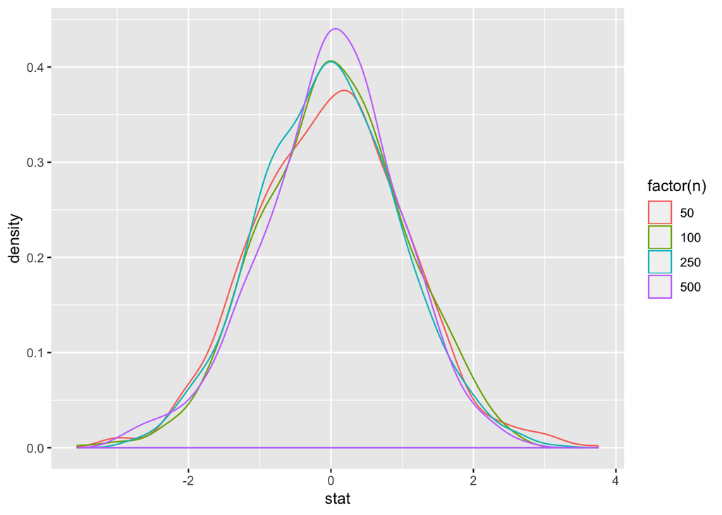

```r
tbl <- as_tibble(df)
ggplot(filter(tbl, loc==0, scale==1)) +
  geom_density(aes(x=stat, col=factor(n)))
```

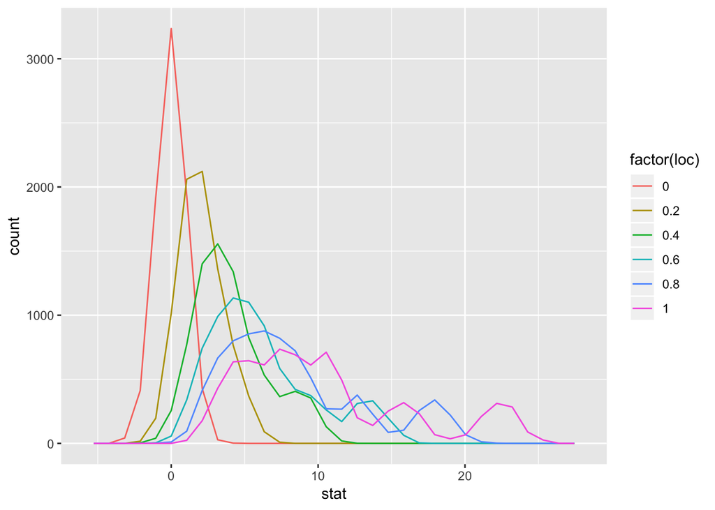

```r
ggplot(tbl) +
  geom_freqpoly(aes(x = stat, col = factor(loc)))
```

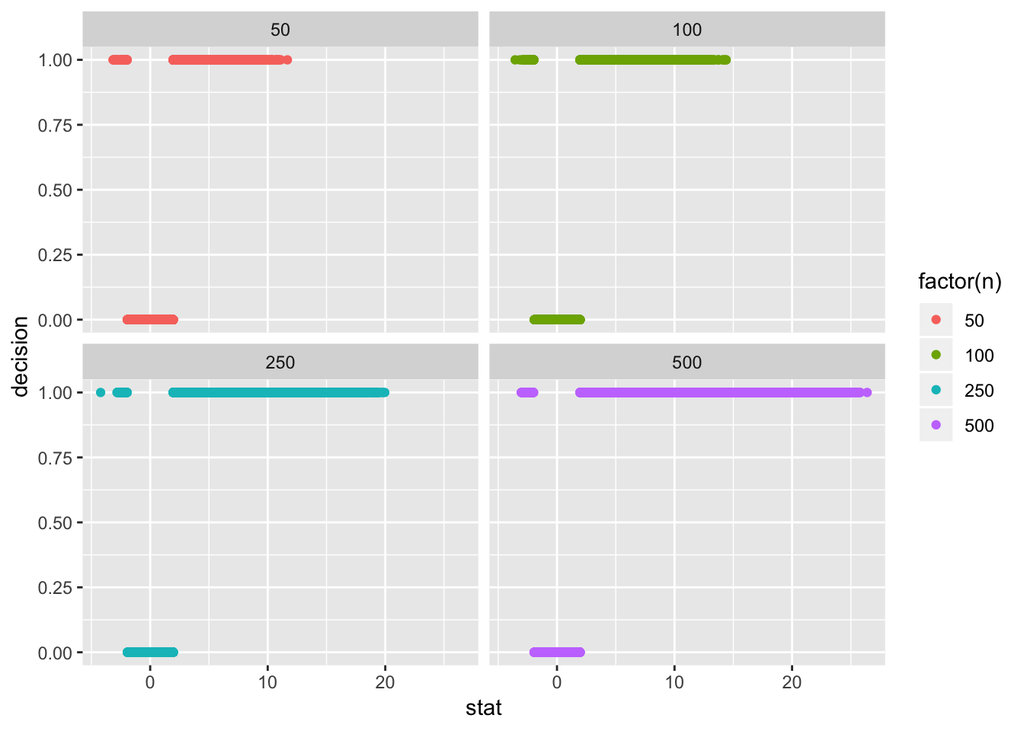

```r
ggplot(tbl) +
  geom_point(aes(x = stat, y = decision, col = factor(n))) +
  facet_wrap(facets = ~n)
```

## More Examples

### Comparison of Two Estimators

Here, we consider a second example: the evaluation of estimators. In particular, we compare the *mean()* and the *median()* as estimators for the expected value of a Gaussian random variable. This example serves to illustrate the use of the optional arguments of the *MakeTable()* function.

First, we specify the function of interest: *mean_vs_median()* (defined below) generates a sample of *n* normal distributed random variables with standard deviation *scale*. It then calculates the *mean()* and the *median()* and returns both in a list.

```r
mean_vs_median <- function(n,scale){

# generate sample
  sample <- rnorm(n, 0, scale)

# calculate estimators
  mean_sample <- mean(sample)
  median_sample <- median(sample)

# return results
  return(list("mean" = mean_sample, "median" = median_sample))
}
n_grid <- c(50, 250, 500)
scale_grid <- c(1, 2, 4)
param_list = list("n" = n_grid, "scale" = scale_grid)
```

```r
# run simulation:
erg_mean_median <- MonteCarlo(func=mean_vs_median, nrep=1000, param_list=param_list)
```

We can check the summary of the simulation:

```r
summary(erg_mean_median)
```

```
## Simulation of function:
##
## function(n,scale){
##
## # generate sample
##   sample <- rnorm(n, 0, scale)
##
## # calculate estimators
##   mean_sample <- mean(sample)
##   median_sample <- median(sample)
##
## # return results
##   return(list("mean" = mean_sample, "median" = median_sample))
## }
## <bytecode: 0x7fcf2a0b6cb0>
##
## Required time: 1.18 secs for nrep = 1000  repetitions on 1 CPUs
##
## Parameter grid:
##
##      n : 50 250 500
##  scale : 1 2 4
##
##
## 2 output arrays of dimensions: 3 3 1000
```

Like before, we pass the function and the parameter grid to *MonteCarlo()* and then feed the results to *MakeTable()*.

```r
MakeTable(output=erg_mean_median, rows="n", cols="scale", digits=2, include_meta=FALSE)
```

```
## \begin{table}[h]
## \centering
## \resizebox{ 1 \textwidth}{!}{%
## \begin{tabular}{ rrrrr }
## \hline\hline\\\\
## n/scale &  & 1 & 2 & 4 \\
##  &  &  &  &  \\
## 50 &  & 0.01 & 0.02 & 0.02 \\
## 250 &  & 0.00 & 0.00 & 0.01 \\
## 500 &  & 0.00 & 0.00 & 0.00 \\
## \\
## \\
## \hline\hline
## \end{tabular}%
## }
## \caption{ mean  }
## \end{table}
##
##
##
## \begin{table}[h]
## \centering
## \resizebox{ 1 \textwidth}{!}{%
## \begin{tabular}{ rrrrr }
## \hline\hline\\\\
## n/scale &  & 1 & 2 & 4 \\
##  &  &  &  &  \\
## 50 &  &  0.01 &  0.03 &  0.02 \\
## 250 &  &  0.00 &  0.00 &  0.02 \\
## 500 &  &  0.00 &  0.00 & -0.01 \\
## \\
## \\
## \hline\hline
## \end{tabular}%
## }
## \caption{ median  }
## \end{table}
```

Again, the default behavior of *MakeTable()* is to print separate tables for each value in the list returned by *func*.

To include both, the estimates for the mean and median in the same table, we simply include the string “list” in either *rows* or *cols*. Here, we choose to include it as the last element of *cols*, to have the results for *mean()* and *median()* next to each other.

```r
MakeTable(output=erg_mean_median, rows=c("n"), cols=c("scale","list"), digits=2, include_meta=FALSE)
```

```
## \begin{table}[h]
## \centering
## \resizebox{ 1 \textwidth}{!}{%
## \begin{tabular}{ rrrrrrrrr }
## \hline\hline\\\\
##  list && \multicolumn{ 3 }{c}{ mean } &  & \multicolumn{ 3 }{c}{ median } \\
## n/scale &  & 1 & 2 & 4 &  & 1 & 2 & 4 \\
##  &  &  &  &  &  &  &  &  \\
## 50 &  &  0.01 &  0.02 &  0.02 &  &  0.01 &  0.03 &  0.02 \\
## 250 &  &  0.00 &  0.00 &  0.01 &  &  0.00 &  0.00 &  0.02 \\
## 500 &  &  0.00 &  0.00 &  0.00 &  &  0.00 &  0.00 & -0.01 \\
## \\
## \\
## \hline\hline
## \end{tabular}%
## }
## \caption{ mean, median  }
## \end{table}
```

The results in the tables above are hard to interpret, due to their scale. Both the *mean()* and *median()* have a bias that is close to zero, and there is barely a difference in the rounded values. However, if we change the number of digits displayed, we see that the bias of the *mean()* tends to be smaller than that of the *median()*.

```r
MakeTable(output=erg_mean_median, rows=c("n"), cols=c("scale","list"), digits=4, include_meta=FALSE)
```

```
## \begin{table}[h]
## \centering
## \resizebox{ 1 \textwidth}{!}{%
## \begin{tabular}{ rrrrrrrrr }
## \hline\hline\\\\
##  list && \multicolumn{ 3 }{c}{ mean } &  & \multicolumn{ 3 }{c}{ median } \\
## n/scale &  & 1 & 2 & 4 &  & 1 & 2 & 4 \\
##  &  &  &  &  &  &  &  &  \\
## 50 &  &  0.0074 &  0.0211 &  0.0250 &  &  0.0110 &  0.0255 &  0.0212 \\
## 250 &  & -0.0007 &  0.0005 &  0.0103 &  & -0.0005 & -0.0036 &  0.0205 \\
## 500 &  &  0.0012 & -0.0013 & -0.0044 &  &  0.0006 & -0.0021 & -0.0121 \\
## \\
## \\
## \hline\hline
## \end{tabular}%
## }
## \caption{ mean, median  }
## \end{table}
```

A simple way to make these differences visible without displaying to many digits is to change the unit, for example by multiplying all results with 100. This is where the *transform* argument of *MakeTable()* comes in handy.

```r
MakeTable(output=erg_mean_median, rows=c("n"), cols=c("scale","list"), digits=2, transform=list(function(x){x*100}, function(x){x*100}), include_meta=FALSE)
```

```
## \begin{table}[h]
## \centering
## \resizebox{ 1 \textwidth}{!}{%
## \begin{tabular}{ rrrrrrrrr }
## \hline\hline\\\\
##  list && \multicolumn{ 3 }{c}{ mean } &  & \multicolumn{ 3 }{c}{ median } \\
## n/scale &  & 1 & 2 & 4 &  & 1 & 2 & 4 \\
##  &  &  &  &  &  &  &  &  \\
## 50 &  &  0.74 &  2.11 &  2.50 &  &  1.10 &  2.55 &  2.12 \\
## 250 &  & -0.07 &  0.05 &  1.03 &  & -0.05 & -0.36 &  2.05 \\
## 500 &  &  0.12 & -0.13 & -0.44 &  &  0.06 & -0.21 & -1.21 \\
## \\
## \\
## \hline\hline
## \end{tabular}%
## }
## \caption{ mean, median  }
## \end{table}
```

### Non-nested data Generating Process

One of the key concepts behind the design of *MonteCarlo()* is that it is generally assumed that the samples are generated from a data generated process that nests all the situations of interest. This is also the case in the examples discussed so far, where the data is generated from a normal distribution and only the standard deviation of the distribution and the number of observations change.

However, this does not mean that *MonteCarlo()* cannot handle non-nested data generating processes. As an example, we consider the case where we want to compare the standard deviation of the *mean()* and the *median()* as we did above, but for samples from a normal distribution and from a uniform distribution.

These are clearly non-nested. To deal with this situation, we include *DGP* as an additional argument in *mean_vs_median()* and create a case distinction, so that the value of *DGP* determines from which distribution the sample is generated. We then include the possible values of *DGP* in an additional parameter grid.

```r
mean_vs_median<-function(n,scale,DGP){

  # generate sample

  if(DGP=="normal"){sample<-rnorm(n, 0, scale)}

  if(DGP=="uniform"){
    b<-scale/(2*sqrt(1/12))
    sample<-runif(n, -b, b)
  }

  # calculate estimators
  mean_sample <- mean(sample)
  median_sample <- median(sample)

  # return results
  return(list("mean" = mean_sample, "median" = median_sample))
}
# create the grid
n_grid <- c(50, 250, 500)
scale_grid <- c(1, 2, 4)
DGP_grid <- c("normal", "uniform")
param_list = list("n" = n_grid, "scale" = scale_grid, "DGP" = DGP_grid)
```

Note that the width of the uniform distribution is specified so that both the normal and the uniform distribution have a standard deviation of *scale*.

```r
erg_mean_median <- MonteCarlo(func = mean_vs_median, nrep=1000, param_list=param_list)
```

After running the simulation, we obtain the following results.

```r
MakeTable(output=erg_mean_median, rows=c("n","DGP"), cols=c("scale", "list"), digits=2, collapse=list("sd", "sd"), include_meta=FALSE)
```

```
## \begin{table}[h]
## \centering
## \resizebox{ 1 \textwidth}{!}{%
## \begin{tabular}{ rrrrrrrrrr }
## \hline\hline\\\\
## & list && \multicolumn{ 3 }{c}{ mean } &  & \multicolumn{ 3 }{c}{ median } \\
## DGP & n/scale &  & 1 & 2 & 4 &  & 1 & 2 & 4 \\
##  &  &  &  &  &  &  &  &  &  \\
## \multirow{ 3 }{*}{ normal } & 50 &  & 0.14 & 0.29 & 0.58 &  & 0.17 & 0.35 & 0.69 \\
##  & 250 &  & 0.06 & 0.13 & 0.24 &  & 0.08 & 0.16 & 0.30 \\
##  & 500 &  & 0.04 & 0.09 & 0.18 &  & 0.05 & 0.11 & 0.22 \\
##  &  &  &  &  &  &  &  &  &  \\
## \multirow{ 3 }{*}{ uniform } & 50 &  & 0.14 & 0.28 & 0.58 &  & 0.24 & 0.48 & 1.02 \\
##  & 250 &  & 0.06 & 0.13 & 0.25 &  & 0.11 & 0.22 & 0.42 \\
##  & 500 &  & 0.04 & 0.09 & 0.17 &  & 0.08 & 0.15 & 0.29 \\
## \\
## \\
## \hline\hline
## \end{tabular}%
## }
## \caption{ mean, median  }
## \end{table}
```

We can the explore the data with *MakeFrame()* and plot it according to the needs of our analysis.

```r
df <- as_tibble(MakeFrame(erg_mean_median))
head(df)
```

```
## # A tibble: 6 x 5
##       n scale DGP           mean   median
##   <dbl> <dbl> <fct>        <dbl>    <dbl>
## 1    50     1 DGP=normal -0.0705  0.0368
## 2   250     1 DGP=normal  0.0186  0.103
## 3   500     1 DGP=normal -0.0415 -0.00378
## 4    50     2 DGP=normal  0.221   0.169
## 5   250     2 DGP=normal  0.0990  0.0341
## 6   500     2 DGP=normal -0.0724 -0.0477
```

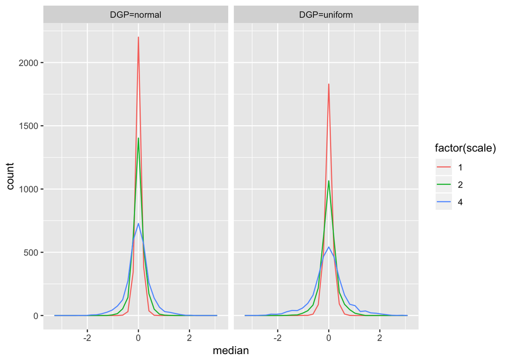

```r
ggplot(df) +
  geom_freqpoly(aes(x = median, col = factor(scale))) +
  facet_wrap(~DGP)
```

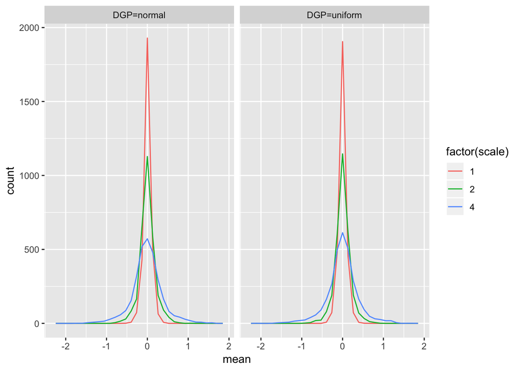

```r
ggplot(df) +
  geom_freqpoly(aes(x = mean, col = factor(scale))) +
  facet_wrap(~DGP)
```

These examples shows that *MonteCarlo()* is very versatile. Depending on the specification of *func*, it is possible to deal with nested or non-nested DGPs. Similarly, multivariate outputs could be handled by splitting them in several elements and returning them seperately.

## Appendix: The MonteCarlo() Functions

### Arguments of MonteCarlo()

The most important argument of *MonteCarlo()* is *func*. It is a user defined function that handles the generation of data, the application of the method of interest and the evaluation of the result for a single repetition and parameter combination.

*MonteCarlo()* handles the generation of loops over the desired parameter grids, the repetition of the Monte Carlo experiment for each of the parameter constellations and (if desired) the parallelization of this process.

There are two important formal requirements that func has to fulfill.

1. The arguments of func have to be scalar.
2. The value returned by func has to be a list of (unnamed) scalars. (The list elements can be named).

In addition to that, *func* has to work in the current workspace. That means that the required packages, data, other function, etc., have to be loaded.

The second most important argument of *MonteCarlo()* is *param_list*, that also has to fulfill some conventions:

1. It is a list.
2. The list elements are named after the arguments of *func*.
3. Each element of the list is a vector or scalar.
4. The list contains as many elements as there are required arguments for *func*.

The only other required argument of *MonteCarlo()* is *nrep* that determines the desired number of repetitions. Apart from that, there is a number of optional arguments that are listed in the table below.

| Argument | Description |
| --- | --- |
| *func* | The function to be evaluated. |
| *nrep* | An integer that specifies the desired number of Monte Carlo repetitions. |
| *param_list* | A list whose components are named after the parameters of *func* and each component is a vector containing the desired grid values for that parameter. |
| *ncpus* | An integer specifying the number of CPUs to be used. Default is *ncpus=1*. For *ncpus>1* the simulation is parallized automatically using *ncpus* CPU units. |
| *max_grid* | Integer that specifies for which grid size to throw an error, if grid becomes to large. Default is *max_grid=1000*. |
| *time_n_test* | Boolean that specifies whether the required simulation time should be estimated (useful for large simulations or slow functions). See details. Default is *time_n_test=FALSE*. |
| *save_res* | Boolean that specifies whether the results of *time_n_test* should be saved to the current directory. Default is *time_n_test=FALSE*. |

#### max_grid - Warning for Excessively Large Parameter Grids

Large parameter grids quickly lead to exessive time requirements for the simulation study. To prevent this from happening unintentionally (for example by thoughtless definition of *param_list*) an error is thrown, if there are more than 1000 parameter constellations. If it is desired to run the simulation nonetheless, *max_grid* has to be modified accordingly.

#### time_n_test - Estimate of the Time Required for the Simulation

For the estimation of the required simulation time, a separate simulation is run on a reduced grid that only contains the extreme points for each parameter, e.g. the smallest and the largest sample size. This test simulation is carried out with nrep/10 repetitions and the required simulation time is estimated by a linear interpolation. Since the computational complexity is usually a convex function of the sample size and the dimension of the process, this approach tends to overestimate the time required. Nevertheless, it provides a reasonable estimate of the order of magnitude of the time required (minutes, hours or days?).

#### save_res - Save the Results of the Test Run

If *time_n_test* is set to *TRUE*, *save_res* determines whether the results of the smaller test simulation should be saved in the current working directory. This can be useful for larger simulations, where the simulation takes a lot of time and it can be useful to have a look at the preliminary results to stop the main simulation if something is not right.

#### raw - Summarize the Output by Averaging Over the nrep Repetitions

Sometimes it is not intended to run a large simulation study and to document the results in a LaTeX document. Instead one might want to conduct a little experiment and immediately see the result. If this is desired, one can set *raw=FALSE* and the output array will be aggregated by taking averages of the results for all *nrep* repetitions. For small parameter grids these can be viewed and interpreted directly.

#### export_also - Data Export to the Cluster and Troubleshooting

Different from functions and packages, *MonteCarlo()* currently does not support the automatic export of datasets used in *func* to the cluster. If this is desired, the respective dataset has to be supplied as *export_also$data*. In addition to that, *export_also* opens a backdoor in case of bugs that might hamper the automatic function and package export. To manually export a function or dataset or to load a package, pass a list to *export_also* where the list element is named “functions”, “data” and/or “packages”. For example: `export_also=list("data"=rnorm(100), "functions"=c("function_name_1", "function_name_2"), "packages"="package_name")`.

### Arguments of MakeTable()

As discussed above, the *MakeTable()* function handles the generation of LaTeX tables from the output of *MonteCarlo()*. Like the latter, it only has three required arguments. The first one - *output* - is a *MonteCarlo* object returned by the equally named function. The second and third are *rows* and *cols* that determine the ordering of the resulting table (from the inside to the outside).

If *func* returns a list with more than one element, each list element is shown in a separate table by default. This behavior can be modified by including the string *“list”* at the desired position in either *rows* or *cols*.

Similar to *MonteCarlo()*, *MakeTable()* has a number of optional arguments that allow to modify the appearance of the generated table and the way the simulation results are summarized. An overview of the function arguments is given in the table below. Details will be discussed thereafter.

[output not shown]

#### digits - Determine the Number of Digits Printed

*digits* simply specifies the number of digits to which results are rounded in the table. In contrast to the standard behavior in R, the results will be printed with exactly this number of digits. Trailing zeros will not be dropped. For example, if *digits=2*, 1 will be displayed as 1.00. This makes for nicer formatting of the resulting tables.

#### collapse - Modify the Way the Simulation Results are Aggregated

For a given parameter constellation, there will be *nrep* simulation results in *output*. By default these are aggregated using *mean()*. Therefore, if *func* returns a test decision with the result either specified as 0 (for non-rejection) or 1 (for rejection), as it was the case in the *ttest()*-example, the results will be aggregated to represent the rejection frequency (size or power - depending on the DGP and the parameter constellation). Similarly, if *func* returns a point estimate, the mean of the estimated parameter is given in the table. If *func* returns the deviation of the estimated parameter from its true value, then the table will represent the bias. By the same principle, MSEs can be calculated if *func* returns squares of these values.

Even though the standard behavior is very versatile, one might be interested in a different aspect of the simulated distribution - for example a quantile such as the median. Therefore the *collapse* argument allows to supply other functions that can be used to aggregate the output. An example could be median() or sd(). These functions are supplied to *collapse* in form of a list of the same length as the output of *func*. Note also that the functions that are specified have to return scalars.

#### transform - Apply Transformations to the Generated Tables

Another option is to apply a transformation directly to the table. This can be useful in situations where the resulting numbers are very small or very large so that one wants to scale them by a power of 10 or 1/10. Another example would be if one wants to show root mean squared errors instead of MSEs.

#### include_meta - Include Information from summary() in Comments Under the Table

By default the information returned by *summary()* - such as the specification of *func*, the parameter grids used in the simulation, the number of repetitions *nrep* and the required simulation time - are included in comments below the table. This is meant as a form of automatic documentation that allows for the replication of results in reports, papers or presentations, even if they were generated some time ago.

If this is not in the interest of the user - or the comments are just perceived as lengthy, this feature can be switched off by setting *include_meta=FALSE*.

#### width_mult - Modify Width of the Table Relative to Text

Without further modifications the LaTeX tables returned by *MakeTable()* are scaled to have the same width as the text in the document. This can be modified directly in the LaTeX code that is returned, but if the user already knows in advance that the table should be smaller, this can already specified by setting *width_mult* to the desired fraction of the text width.

#### partial_grid - Print Table Only for Subsets of the Original Parameter Grid

Sometimes situations will occur in which one is only interested in a subset of the parameter grid originally considered and passed to *MonteCarlo()*. For example because it turns out that the resulting table is very large, or because the results are not very informative for some values of the grid (e.g. the power of a test remains at 1 if the sample size is increased further).

[^1]: See: MonteCarlo package https://cran.r-project.org/web/packages/MonteCarlo/